# Sessão 4.4: Correlação

Norberto Jorge Gonçalves

6 de Julho de 2025

# 1. Correlação: Relação entre Variáveis Numéricas

A correlação é uma medida estatística que descreve a força e a direção da relação linear entre duas variáveis numéricas. É uma ferramenta fundamental na análise exploratória de dados.

## 1.1. O Coeficiente de Correlação de Pearson

O coeficiente de correlação de Pearson (geralmente denotado por r) é a medida mais comum para correlação linear. Varia entre -1 e +1.

```
+1: Correlação positiva perfeita (à medida que uma variável aumenta, a outra também aumenta de forma linear).
-1: Correlação negativa perfeita (à medida que uma variável aumenta, a outra diminui de forma linear).
0: Nenhuma correlação linear (não significa que não haja outra forma de relação, apenas não linear).
Valores próximos de 0: Correlação linear fraca.
Valores próximos de +1 ou -1: Correlação linear forte.
```

**Importante:** Correlação NÃO implica causalidade!

Vamos usar o dataset mtcars para demonstrar.

```r
# Carregar o dataset mtcars
data(mtcars)
head(mtcars)
```

|  | mpg | cyl | disp | hp | drat | wt | qsec | vs | am | gear | carb |
| --- | --- | --- | --- | --- | --- | --- | --- | --- | --- | --- | --- |
| Mazda RX4 | 21.0 | 6 | 160 | 110 | 3.90 | 2.620 | 16.46 | 0 | 1 | 4 | 4 |
| Mazda RX4 Wag | 21.0 | 6 | 160 | 110 | 3.90 | 2.875 | 17.02 | 0 | 1 | 4 | 4 |
| Datsun 710 | 22.8 | 4 | 108 | 93 | 3.85 | 2.320 | 18.61 | 1 | 1 | 4 | 1 |
| Hornet 4 Drive | 21.4 | 6 | 258 | 110 | 3.08 | 3.215 | 19.44 | 1 | 0 | 3 | 1 |
| Hornet Sportabout | 18.7 | 8 | 360 | 175 | 3.15 | 3.440 | 17.02 | 0 | 0 | 3 | 2 |
| Valiant | 18.1 | 6 | 225 | 105 | 2.76 | 3.460 | 20.22 | 1 | 0 | 3 | 1 |

## 1.2. Calcular Correlação em R (cor())

A função `cor()` calcula o coeficiente de correlação entre duas variáveis ou entre todas as pares de variáveis numéricas num data frame.

### 1.2.1. Correlação entre Duas Variáveis

Vamos ver a correlação entre mpg (milhas por galão - eficiência de combustível) e hp (cavalos de potência).

```r
# Correlação entre mpg e hp
cor_mpg_hp <- cor(mtcars$mpg, mtcars$hp)
print(paste("Correlação entre MPG e HP:", round(cor_mpg_hp, 2)))
```

```
## [1] "Correlação entre MPG e HP: -0.78"
```

Interpretação: Um valor de aproximadamente -0.78 sugere uma forte correlação negativa. À medida que os cavalos de potência aumentam, a eficiência de combustível (MPG) tende a diminuir. Vamos ver a correlação entre wt (peso) e qsec (tempo no quarto de milha).

```r
# Correlação entre wt e qsec
cor_wt_qsec <- cor(mtcars$wt, mtcars$qsec)
print(paste("Correlação entre Peso e QSEC:", round(cor_wt_qsec, 2)))
```

```
## [1] "Correlação entre Peso e QSEC: -0.17"
```

Interpretação: Um valor de aproximadamente -0.17 sugere uma correlação negativa muito fraca.

### 1.2.2. Matriz de Correlação

Podemos calcular a correlação entre todas as pares de variáveis numéricas num data frame criando uma matriz de correlação.

```r
library(dplyr)
# Selecionar apenas as colunas numéricas do mtcars
mtcars_numericas <- mtcars %>%
  select(mpg, cyl, disp, hp, drat, wt, qsec, vs, am, gear, carb)

# Calcular a matriz de correlação
matriz_correlacao <- cor(mtcars_numericas)
print(round(matriz_correlacao, 2)) # Arredondar para melhor visualização
```

```
##        mpg   cyl  disp    hp  drat    wt  qsec    vs    am  gear  carb
## mpg   1.00 -0.85 -0.85 -0.78  0.68 -0.87  0.42  0.66  0.60  0.48 -0.55
## cyl  -0.85  1.00  0.90  0.83 -0.70  0.78 -0.59 -0.81 -0.52 -0.49  0.53
## disp -0.85  0.90  1.00  0.79 -0.71  0.89 -0.43 -0.71 -0.59 -0.56  0.39
## hp   -0.78  0.83  0.79  1.00 -0.45  0.66 -0.71 -0.72 -0.24 -0.13  0.75
## drat  0.68 -0.70 -0.71 -0.45  1.00 -0.71  0.09  0.44  0.71  0.70 -0.09
## wt   -0.87  0.78  0.89  0.66 -0.71  1.00 -0.17 -0.55 -0.69 -0.58  0.43
## qsec  0.42 -0.59 -0.43 -0.71  0.09 -0.17  1.00  0.74 -0.23 -0.21 -0.66
## vs    0.66 -0.81 -0.71 -0.72  0.44 -0.55  0.74  1.00  0.17  0.21 -0.57
## am    0.60 -0.52 -0.59 -0.24  0.71 -0.69 -0.23  0.17  1.00  0.79  0.06
## gear  0.48 -0.49 -0.56 -0.13  0.70 -0.58 -0.21  0.21  0.79  1.00  0.27
## carb -0.55  0.53  0.39  0.75 -0.09  0.43 -0.66 -0.57  0.06  0.27  1.00
```

A matriz de correlação mostra o coeficiente de correlação para cada par de variáveis. A diagonal principal é sempre 1 (uma variável correlaciona-se perfeitamente consigo mesma). A matriz é simétrica.

## 1.3. Visualizar Correlação (Gráfico de Dispersão)

Um gráfico de dispersão (plot()) é a melhor forma de visualizar a relação entre duas variáveis numéricas e ter uma ideia da sua correlação.

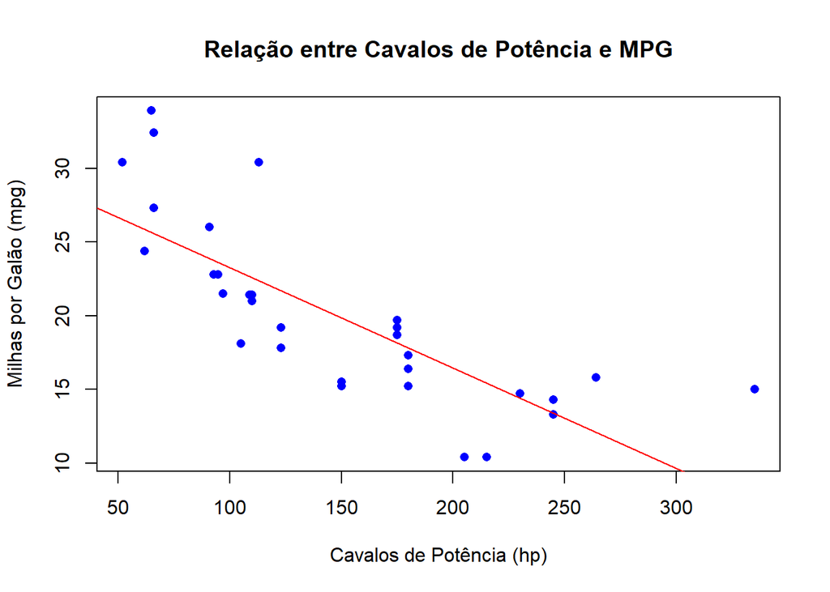

```r
# Gráfico de dispersão entre mpg e hp
plot(mtcars$hp, mtcars$mpg,
     main = "Relação entre Cavalos de Potência e MPG",
     xlab = "Cavalos de Potência (hp)",
     ylab = "Milhas por Galão (mpg)",
     pch = 16, # Tipo de ponto
     col = "blue") # Cor dos pontos

# Adicionar uma linha de tendência (opcional)
abline(lm(mpg ~ hp, data = mtcars), col = "red")
```

Este gráfico confirma a forte relação negativa: à medida que os cavalos de potência aumentam (para a direita no eixo X), as milhas por galão diminuem (para baixo no eixo Y).

## 1.4. Correlação e Valores em Falta

Se houver valores NA nas variáveis, a função cor() por padrão retornará NA. Para ignorar os NAs, use o argumento use = “pairwise.complete.obs” ou use = “complete.obs”.

```r
dados_exemplo_na <- data.frame(
  X = c(1, 2, 3, 4, 5),
  Y = c(2, 4, NA, 8, 10)
)

cor(dados_exemplo_na$X, dados_exemplo_na$Y)
```

```
## [1] NA
```

```r
cor(dados_exemplo_na$X, dados_exemplo_na$Y, use = "pairwise.complete.obs")
```

```
## [1] 1
```

Parabéns! Já sabem o que é correlação e como calculá-la e visualizá-la!